# Problem Set 4

Author

Kade Naughton

Published

November 20, 2026

**GitHub repo:** https://github.com/Kade-Naughton/ec422_ps4_naughton

## ARIMA vs. ETS

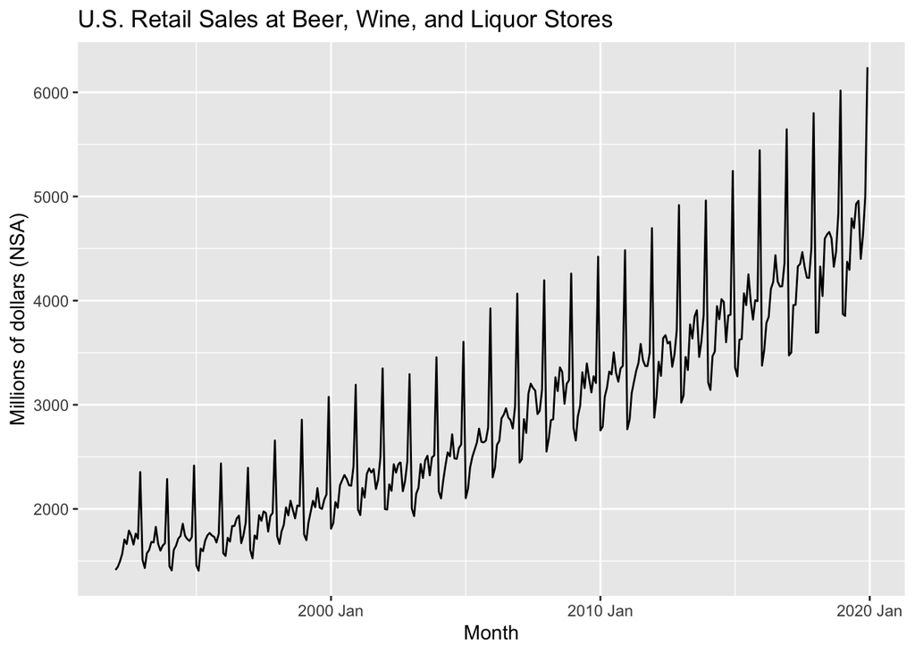

Figure 1: Monthly U.S. sales at beer, wine, and liquor stores.

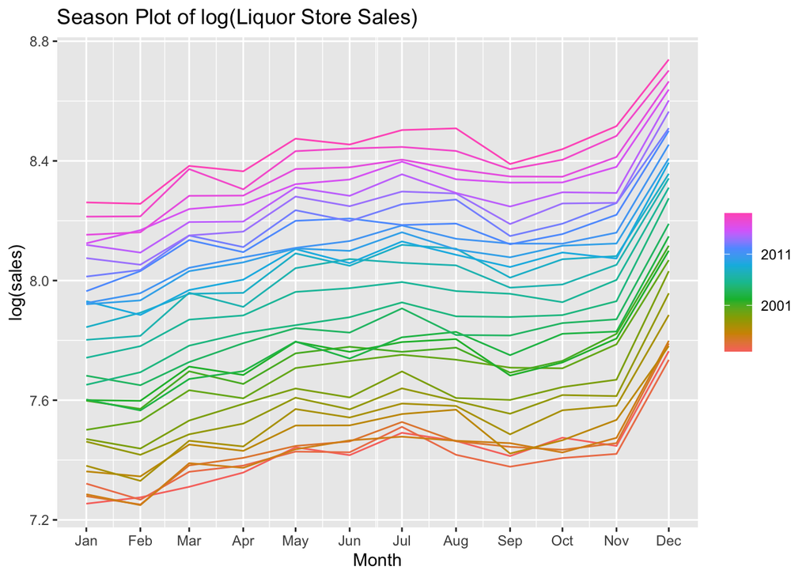

Figure 2: Season plot of log sales, one line per year.

Sales trend steadily upward over the whole sample. The seasonal pattern is strong and regular. December is by far the highest month because of the holidays, there’s a smaller bump from May through August, and January and February are the lowest months. In Figure 1 the seasonal swings get bigger as sales grow, so the seasonality is multiplicative. Taking logs makes the swings about the same size every year, which is why we model log(sales).

```
Series: sales
Model: ARIMA(1,0,2)(2,1,1)[12] w/ drift
Transformation: log(sales)

Coefficients:
         ar1      ma1     ma2    sar1     sar2     sma1  constant
      0.8948  -0.7374  0.2477  0.3679  -0.2334  -0.8845    0.0036
s.e.  0.0355   0.0697  0.0623  0.0668   0.0665   0.0468    0.0001

sigma^2 estimated as 0.0005469:  log likelihood=752.43
AIC=-1488.85   AICc=-1488.4   BIC=-1458.61
```

```
Series: sales
Model: ETS(A,A,A)
Transformation: log(sales)
  Smoothing parameters:
    alpha = 0.3296099
    beta  = 0.007560263
    gamma = 0.0001765132

  Initial states:
     l[0]         b[0]      s[0]      s[-1]        s[-2]       s[-3]      s[-4]
 7.412219 0.0007608238 0.3263441 0.03153301 -0.004849389 -0.03530501 0.02512163
      s[-5]      s[-6]      s[-7]       s[-8]      s[-9]     s[-10]     s[-11]
 0.05558624 0.01219515 0.02503206 -0.06088935 -0.0607952 -0.1578065 -0.1561667

  sigma^2:  7e-04

      AIC      AICc       BIC
-489.1517 -487.2272 -424.2608
```

fable chose an ARIMA(1,0,2)(2,1,1)[12] with drift and an ETS(A,A,A).

The ARIMA has d = 0 and D = 1, so log sales were not differenced month to month, but they were seasonally differenced once. That means the model works with the change in log sales from the same month a year earlier.

For the ETS, the first A means the errors are additive, the second A means the trend is additive (linear), and the third A means the seasonality is additive. Since the model is fit to log sales, additive seasonality in logs is the same as multiplicative seasonality in dollars.

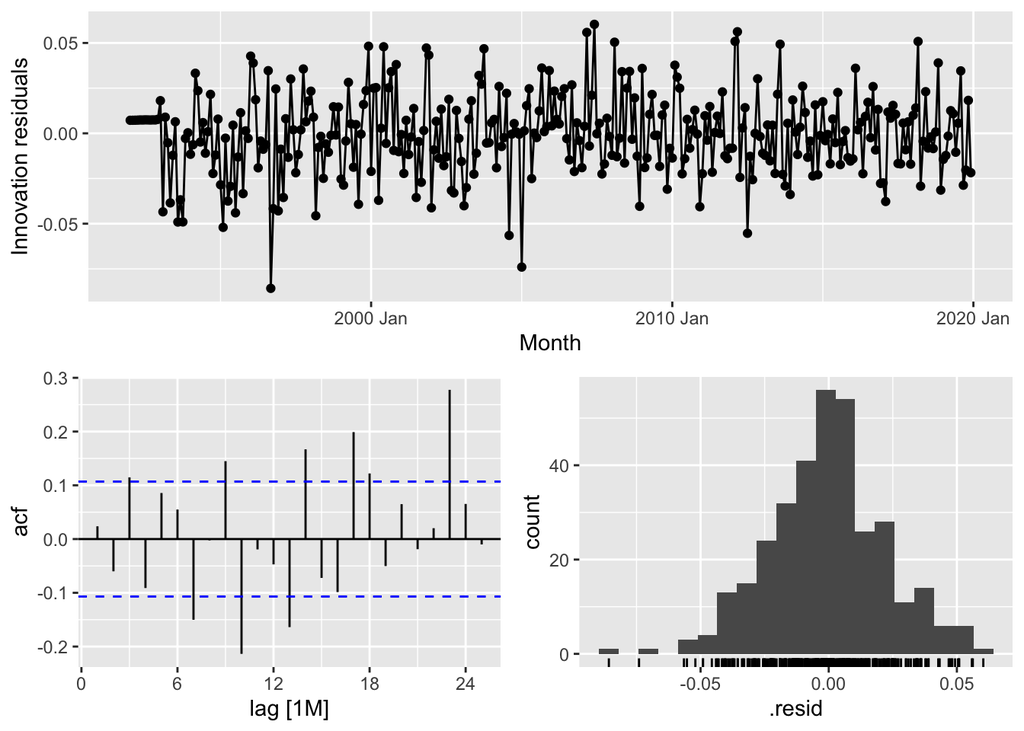

Figure 3: Residual test and Ljung Box for the ARIMA model.

```
# A tibble: 1 × 3
  .model lb_stat lb_pvalue
  <chr>    <dbl>     <dbl>
1 arima     120.         0
```

The model has p + q + P + Q = 1 + 2 + 2 + 1 = 6 estimated AR and MA coefficients, so dof = 6. The Ljung–Box statistic is about 120 with a p-value of essentially zero, so the residuals do not look like white noise. Several spikes in the ACF fall outside the blue bands, with the biggest one at lag 23.

With 336 months in the sample and a first training sample of 120 months, the TS-CV uses 216 forecast origins. The first forecast is for January 2002 and the last is for December 2019.

One-month-ahead forecast accuracy, January 2002 to December 2019.

| .model | .type | RMSE | MAE |
| --- | --- | --- | --- |
| arima | Test | 81.43 | 65.65 |
| ets | Test | 94.35 | 72.31 |
| snaive | Test | 161.26 | 136.63 |

ARIMA forecasts most accurately. It has the lowest RMSE and the lowest MAE, so the two metrics agree.

```
    Diebold-Mariano Test

data:  liquor_errs$arimaliquor_errs$ets
DM = -2.9062, Forecast horizon = 1, Loss function power = 2, p-value =
0.004042
alternative hypothesis: two.sided
```

```
    Diebold-Mariano Test

data:  liquor_errs$arimaliquor_errs$snaive
DM = -10.755, Forecast horizon = 1, Loss function power = 2, p-value <
2.2e-16
alternative hypothesis: two.sided
```

ARIMA vs. ETS has a DM statistic of -2.91 with a p-value of 0.004, and ARIMA vs. the seasonal random walk has a DM statistic of -10.76 with a p-value below 2.2e-16. Both statistics are negative, so ARIMA had the smaller squared errors each time, and both p-values are below 0.05, so ARIMA is significantly more accurate than both. If I were the liquor store chain, I would use the ARIMA model.

## Forecast Combination

Forecast accuracy including the equal-weight ARIMA/ETS combination.

| .model | .type | RMSE | MAE |
| --- | --- | --- | --- |
| arima | Test | 81.43 | 65.65 |
| combo | Test | 85.19 | 66.77 |
| ets | Test | 94.35 | 72.31 |
| snaive | Test | 161.26 | 136.63 |

The combination has an RMSE of 85.19 and an MAE of 66.77. That is better than ETS but worse than ARIMA, so it lands in between the two models that go into it.

```
[1] 0.8782934
```

The ARIMA and ETS forecast errors have a correlation of 0.88, so the two models mostly make the same mistakes and averaging them cancels out very little error. The DM test also showed ARIMA is significantly more accurate than ETS, so averaging in ETS just pulled the forecast toward the worse model. That is why the combination couldn’t beat ARIMA.

## VAR vs. BVAR

We produce 120 forecasts for each variable. The first is for 1990 Q1 and the last is for 2019 Q4.

RMSE of one-quarter-ahead forecasts, 1990 Q1 to 2019 Q4.

| Variable | VAR(1) | VAR(4) | BVAR(4), lambda = 0.3 | BVAR(4), lambda = 0.05 |
| --- | --- | --- | --- | --- |
| gdp | 0.513 | 0.569 | 0.539 | 0.567 |
| cons | 0.460 | 0.527 | 0.486 | 0.495 |
| inv | 2.493 | 2.521 | 2.385 | 2.698 |
| emp | 0.196 | 0.228 | 0.211 | 0.315 |
| infl | 0.208 | 0.207 | 0.197 | 0.330 |
| unrate | 0.199 | 0.215 | 0.203 | 0.216 |
| ffr | 0.390 | 0.497 | 0.414 | 0.358 |
| gs10 | 0.361 | 0.379 | 0.359 | 0.362 |

The VAR(1) forecasts better than the VAR(4) for 7 of the 8 variables, and inflation is basically a tie. Even though the VAR(4) contains the VAR(1) as a special case, it has 264 coefficients instead of 72, and each one is estimated with some error. That extra estimation noise ends up in the forecasts (overfitting), so the smaller model does better.

The BVAR(4) with λ = 0.3 beats the OLS VAR(4) for all 8 variables. They have the same variables and the same lags, so the difference comes from the Minnesota prior shrinking the coefficients toward zero, which cuts down on the estimation noise.

Compared to the VAR(1), the results are mixed. The BVAR is better for investment, inflation, and the 10-year yield, and the VAR(1) is better for the other five, but most of the differences are small.

With λ = 0.05, the forecasts get worse for 7 of the 8 variables, especially employment and inflation. Only the federal funds rate improves. This tells me λ = 0.05 is too much shrinkage, since it pushes the coefficients so close to zero that the model loses real dynamics in the data.

The winner’s RMSE here would not be a fair estimate of how it will forecast in the future. I would be choosing the model based on these same 120 quarters, so some of its edge is luck, and its RMSE would look better than it will actually do going forward. A fair estimate would need data that wasn’t used to pick the model.

```
    Diebold-Mariano Test

data:  e_var4e_bvar
DM = 2.1366, Forecast horizon = 1, Loss function power = 2, p-value =
0.03468
alternative hypothesis: two.sided
```

```
    Diebold-Mariano Test

data:  e_var4e_bvar
DM = 1.4529, Forecast horizon = 1, Loss function power = 2, p-value =
0.1489
alternative hypothesis: two.sided
```

For GDP growth, DM = 2.14 with a p-value of 0.035, so the BVAR is significantly more accurate at the 5% level. For inflation, DM = 1.45 with a p-value of 0.149, so the BVAR does better but the difference isn’t significant. This makes me more careful about the table in 4.3b, since some of the gaps between models could just be noise.

## Factor Model

```
[1] 718 122
```

```
  INDPRO   PAYEMS CPIAUCSL FEDFUNDS
       5        5        6        2
```

INDPRO and PAYEMS both use code 5, which is the monthly growth rate. CPIAUCSL uses code 6, which is the change in the monthly inflation rate. FEDFUNDS uses code 2, which is the first difference, so the monthly change in percentage points.

Industrial production is an index that grows exponentially over time, so the log growth rate makes it stationary. The federal funds rate is already a percent and sat near zero from about 2009 to 2015, where taking logs would blow up, so the change in percentage points makes more sense.

```
                            PC1      PC2      PC3      PC4      PC5
Standard deviation     4.258002 2.993839 2.923106 2.597224 2.295261
Proportion of Variance 0.149840 0.074070 0.070620 0.055750 0.043540
Cumulative Proportion  0.149840 0.223910 0.294530 0.350280 0.393820
```

The first three factors explain 29.5% of the variation in all 121 series, which matches what we saw in class.

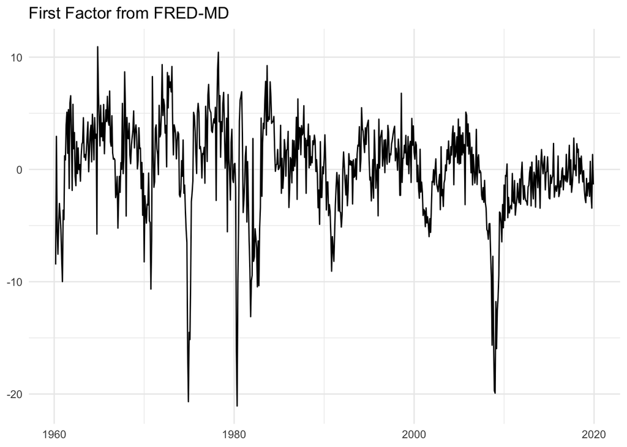

Figure 4: The first factor estimated from FRED-MD, signed to rise with industrial production.

```
   PAYEMS IPMANSICS    USGOOD    INDPRO    MANEMP   IPFPNSS    CUMFNS   DMANEMP
0.8415788 0.8404473 0.8390159 0.8219976 0.8028499 0.7903078 0.7778686 0.7768615
```

```
    CUSR0000SAC DNDGRG3M086SBEA   CUSR0000SA0L2        CPIAUCSL   CUSR0000SA0L5
      0.7468587       0.7391330       0.7279202       0.7198020       0.7020307
       CPITRNSL           PCEPI        CPIULFSL
      0.6806883       0.6795890       0.6570361
```

The first factor is most correlated with employment (PAYEMS, USGOOD, MANEMP, DMANEMP), industrial production (INDPRO, IPMANSICS, IPFPNSS), and manufacturing capacity utilization (CUMFNS), so it captures real activity, or the business cycle. In the plot it drops sharply in big recessions like the early 1980s and 2008–09.

The second factor is most correlated with CPI and PCE price indexes (CPIAUCSL, CPITRNSL, CPIULFSL, PCEPI, and others), so it captures prices, or inflation.

```
  RMSE_AR   RMSE_FA
0.6168431 0.5887272
```

I get an RMSE of 0.617 for the AR(1) and 0.589 with the factors, which matches the numbers from class. Estimating the factors once on the full sample would be cheating, because at a forecast origin like 1995 the factors would be using data through 2019 that nobody had yet. That would make the factor model look better than it could actually do in real time.

Direct 12-month-ahead forecasts of CPI inflation, with and without factors.

| series | forecasts | RMSE_AR | RMSE_FA | MAE_AR | MAE_FA | DM_pvalue |
| --- | --- | --- | --- | --- | --- | --- |
| CPIAUCSL | 349 | 2.1079 | 1.8937 | 1.5777 | 1.3494 | 4e-04 |

Yes, the factors improve the forecast of 12-month CPI inflation. The RMSE drops from 2.108 to 1.894, about a 10.2% reduction, and the DM p-value is 0.0004, so the difference is statistically significant.

## Reflection

The biggest thing I took away from this problem set is that simple models are hard to beat, especially when there isn’t much data compared to the number of parameters. The VAR(1) beat the VAR(4), and a lot of the differences between models weren’t statistically significant once I actually tested them. The same idea kept coming up in different forms, which was giving up a little bias to cut down on estimation noise. Shrinkage in the BVAR, equal weights in the combination, and factors that squeeze 121 series down to three all let a model use a lot of information without estimating a lot of parameters. I also learned that how the test is set up matters, like re-estimating the factors at every forecast origin instead of using the full sample. I feel like I have a better understanding of the forecasting process in general now. As before, AI disclosure as AI was used to help fix broken code. I went back and reviewed its corrections and spent time understanding why my code didn’t and why the generative code was successful. AI was sparsely used for the write up, mainly to fix clunky hard to understand wording. All was reviewed by me, and edited as needed.